# CS 372/472 & LRN_SCI 372/472

Networks (cont.)

Prof. Connor Bain

connor.bain@northwestern.edu

May 14, 2026

## Logistical Stuff

**No HW this weekend.**

- work on your projects

**Reminder**

- No class **Tuesday, May 19th**. I’ll send an announcement on Canvas with office hours details for project meetings.

## Model towards a question

> “All models are wrong, but some are useful.” (Box 1979)
- Don’t add parameters / content **just because it’s more realistic.**
- Instead, add **only if it helps us answer our question.**

### Advantages of Simplicity

- Helps confirm the mechanisms you modeled are actually necessary
- Makes it easier to understand the model and its behavior
- Facilitates *verification* of the model (i.e., confirming that the model is implemented correctly and behaves as intended)
- Facilitates *validation* of the model (i.e., comparing the model’s behavior to real-world data)

## Connections are different these days

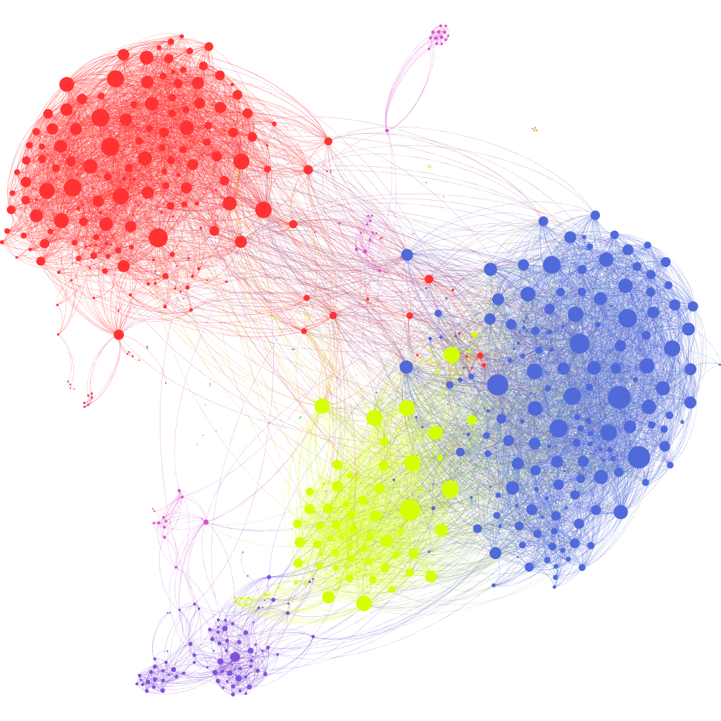

Social Network Graph

## Basic Terminology

- In NetLogo, we call these connections `links` (just like in network theory)
  - Our `nodes` can be any other agents (i.e. `turtles`, `patches`)
- The degree of a node is how many links it has
- A path is a collection of links that connect two nodes
- The length of a path is how many links in the path
- The clustering coefficient of a node is the ratio of existing links connecting a node’s neighbors to each other to the maximum possible number of such links.

## Regular Networks

- All nodes have the same degree. Picture a 2D lattice.

## Erdös-Renyi Random Network

A randomized algorithm for generating networks. About the simplest formation model possible.

- Begin with `n` isolated vertices, no edges
- Add edges gradually, one at a time
- Edges are added in a random, unbiased fashion

## Our first 3 networks

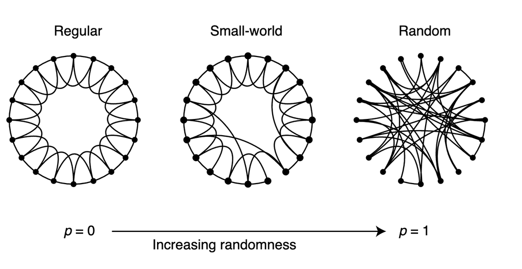

Network types

## Scale-Free Networks

- A network where *any subnetwork* of the global network has the same properties as the global network.
- A common method to create it is to adding new nodes and links to a system so that extant nodes with a large number of links are more likely to receive new connections.
- This tends to produce networks with central nodes that have many radiating links (a “hub and spoke” network)

# But how can we use this to inform ABM design?

## The Bass Model

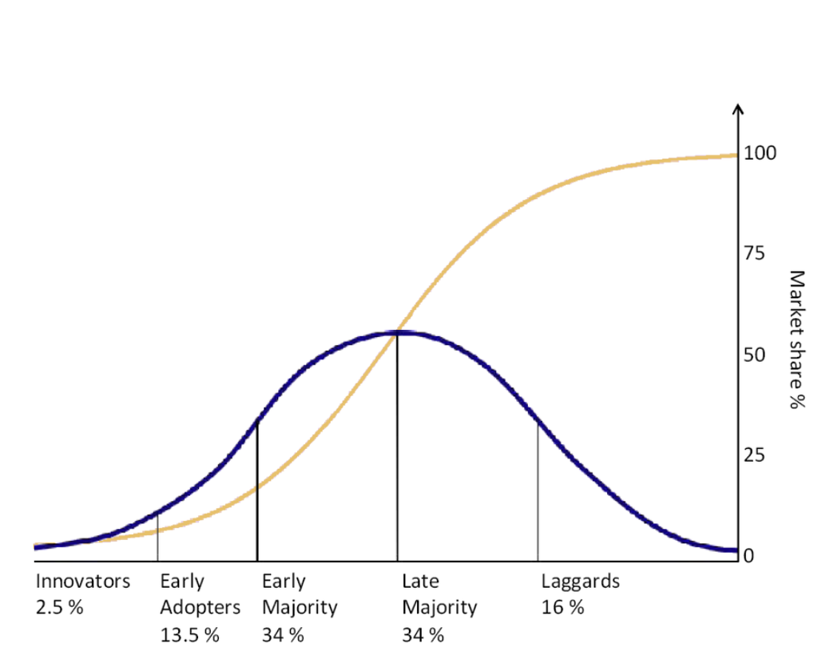

Typical Pattern of Innovation Diffusion

## How could we use ABM to explore this?

- Informally, *“how does novel information diffuse through a population over time?”*

## The Agent-based Version

- Setup `m` agents
- Each `tick` agents determine if they will innovate on the basis of:
- $p_a$ – innovation
- $q_a$ – imitation on the basis of other adopters
- Observe number of adopters

## Version 1

- Create `m` agents and a slider to control the number of agents
- Have them adopt at each time step randomly

> Optional: different thresholds for adoption of each agent

## Scope and Question

- Before moving on to version 2…
- Let’s revisit our *driving question* to focus in on the advantages of ABM in this context:
  - network heterogeneity
  - local but complex interactions
  - some individuals may have more information sources than others

> DQ: “How does novel information diffuse through a population embedded in a social network based on both broadcast and local information drivers”

## Our agents

- What are the agents in the model?
- **Granularity / Level of the agent**? (related to temporal scale of interest)
  - Cellular-level
  - Organizational-level
  - Individual-Human Level
- Do we need *proto-agents*?
  - Agents that do not have their own properties / behaviors but may in the future

## Environment

- What is the environment within which the agents act?
- Diffusion:
  - The Social Network
  - To some extent Media

## Time step

- What happens in a single time step of the model?
- Diffusion
  - Each agent decides whether or not to adopt the information
  - They update their internal state
  - Overall statistics are calculated

## Model 2 - Adoption Rules

- Add `broadcast-influence` and `social-influence` sliders to the model
- Have agents adopt based on the Bass model so agents adopt either due to:
  1. `broadcast-influence`
  2. `social-influence * fraction-of-adopters`

## Inputs and Outputs

- Inputs / Parameters
  - Diffusion
    - The network structure
    - Effect of Social Influence
    - Effect of Mass Media
    - Number of Agents
- Outputs / Measures
  - Diffusion
    - Number of Adoptions over Time

## Version 3 - Plotting Results (advantage of ABM)

- Plot the Adoption Rate over time
- Stop the model if no one is left to adopt

> Optional: Plot the different types of adoption (due to broadcast vs. social) separately

## Version 4 - Networks!

- Add a *Random Network* to the model
- Adoption Rule Change
  - Rather than social-influence being modified by the whole population of adopters, it is only modified by the local neighborhood

> Optional: Set up a distribution for the density of agents

## Version 5 - Repeat Experiments

- Add a `reset innovation` button so you can run on the same network multiple times

## Version 6 - Different Network Structures

- Create a chooser to choose different network structures
- Create a slider to choose network density
- If we move from a regular 2D lattice to a *Watts-Strogatz small-world* network by rewiring only 5% of the edges, we drastically reduce the average path length.
  - In a disease model, would this rewire make the system more ‘stable’ or more ‘volatile’? How would it promote or inhibit the spread of information?
- In a scale-free network, a few hubs hold the system together. If your agents are programmed to ‘follow the leader,’ how does the degree distribution affect the diversity of opinions in your model?
  - What happens to the system’s robustness if we remove the top 1% of nodes?

## Version 7 - Different Types of Agents

- Create a second type of agent (“An Influencer”)
- Add a weight that controls how influential they are
- Plot adoption across agent types

## Analyzing the Model

- Now that we have a model we would like to **analyze** it
- For instance, we might ask, “If we hold `broadcast-influence` constant, what is the effect of different `social-influence` values on the total adoption rate for each type of agent?”

## Multiple Runs and Parameter Sweeping

- We can use BehaviorSpace and then analyze outputted data in some comfortable manner
- Whenever a model has stochastic components, you must do multiple runs. **randomness can be accounted for!**
- You also want to be able to systematically alter an input parameter

## References

Box, George EP. 1979. “Robustness in the Strategy of Scientific Model Building.” In *Robustness in Statistics*. Elsevier.